# Jupyter Notebook Example

## Jupyter Notebook Example

This is an example jupyter notebook to show some features of the tool. Find some other jupyter's tips on [towards data science](https://towardsdatascience.com/15-tips-and-tricks-for-jupyter-notebook-that-will-ease-your-coding-experience-e469207ac95c).

### Some Magic

Let's start with some magic commands

```python
%%capture
!pip install pandas matplotlib
```

Here is the first bit of magic:

- `%%catpure` is a magic command that will capture, hence hide the output of a cell
  - Jupyter magic commands come from [IPython](https://ipython.readthedocs.io/en/stable/interactive/magics.html) and will usually start with `%`, use `%magic` for info.
- `!` in front of the next command allow me to execute a command directly in the terminal
  - Here I use this command to install some dependencies

```python
%%HTML
<p> Look at that html! 🤯</p>
<svg width="100" height="100">
  <circle cx="50" cy="50" r="40" stroke-width="4" fill="tomato" />
</svg>
```

Look at that html! 🤯

```python
%%ruby
# Even ruby
puts 'hello world!'
```

```
hello world!
```

## Jupyter Customisation

Let's add some jupyter packages for customization

```python
%%capture
!pip install jupyter_nbextensions_configurator jupyter_contrib_nbextensions jupyterthemes
!jupyter contrib nbextensions install
```

Everytime you install a package or do an extension modification, you'll have to restart the notebook for the effect to be taken into consideration. You should now see a range of feature in a `Nbextension` tab.

You can also customize your notebook...

Here is a full list of the available themes from [towardsdatascience.com](https://towardsdatascience.com/7-essential-tips-for-writing-with-jupyter-notebook-60972a1a8901) which is a *must see* with so many great article about jupyter notebook and datascience!

[figure not shown]

```python
%%capture
# !jt -l                           # To list the available themes
# !jt -t oceans16 -T -N -kl        # To add the theme with tool bar and logo
# !jt -r                           # To remove the theme
```

And like before once you run those commands you will need to restart your jupyter notebook for theme to be accounted for.

Basically it adds a `custom.css` in your `~/.jupyter/` folder.

### Datascience with python

Where we use some libraries installed earlier for basic python example. First you need to import the dependencies

```python
import pandas as pd
import numpy as np
```

```python
# df = pd.read_csv('example.csv', header=0)
df = pd.DataFrame({
    'A':['1','2','2','4','5','2'],
    'B':np.random.randint(5, size=6),
    'C':['first','.','..','...','....','last']})
df.head(3)
```

|  | A | B | C |
| --- | --- | --- | --- |
| 0 | 1 | 1 | first |
| 1 | 2 | 1 | . |
| 2 | 2 | 0 | .. |

Once you have loaded your data you can save it to multiple format like `.csv` with:

```
df.to_csv('example.csv', index=False)
```

Write down some useful methods with pandas dataframe to transform or present your data

```python
df.groupby('A').groups
```

```
{'1': [0], '2': [1, 2, 5], '4': [3], '5': [4]}
```

```python
print("You can get the [ {} ] and [ {} ] of a column"
      .format(df['C'].iat[0], df['C'].iat[-1]))
```

```
You can get the [ first ] and [ last ] of a column
```

```python
print("Number of rows: {}".format(df.shape[0]))
```

```
Number of rows: 6
```

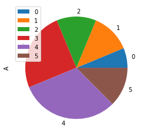

```python
df.drop(['C'], axis=1)
df['A'] = df['A'].apply(lambda x: int(x))
df['B'] = df['B'].apply(lambda x: int(x))
plot = df.plot.pie(y='A')
```